# Spatio-temporal Under-five Mortality Methods for Estimation

## Load Package and Data

`Uganda` contains model survey data provided by DHS. Note that this data is fake, and does not represent any real country’s data. Data similar to the `Uganda` data used in this vignette can be obtained by using `getBirths`. `UgandaMap` contains geographic data from the 1995 Uganda Admin 1 regions defined by DHS. Data similar to the `UgandaMap` data used in this vignette can be obtained by using `read_shape`.

First, we load the package and load the necessary data. INLA is not in a standard repository, so we check if it is available and install it if it is not.

```r
library(SUMMER)
if (!isTRUE(requireNamespace("INLA", quietly = TRUE))) {
  install.packages('INLA', repos = 'https://www.math.ntnu.no/inla/R/stable')
}

data(Uganda)
data(UgandaMap)
```

## Make Country Summary

Next, we obtain Horvitz-Thompson estimators using `countrySummary_mult`.

```r
years <- levels(Uganda[[1]]$time)

data <- countrySummary_mult(births = Uganda, years = years, idVar = "id", regionVar = "region",
                           timeVar = "time", clusterVar = "~clustid+id", ageVar = "age",
                           weightsVar = "weights", geo.recode = NULL)
```

## Read Maps

In this step, we separate the output from `read_shape` to use as function arguments.

```r
    geo <- UgandaMap$geo
    mat <- UgandaMap$Amat
```

## Make Priors

Using our adjacency matrix, we simulate hyperpriors using `simhyper`.

```r
priors <- simhyper(R = 2, nsamp = 1e+05, nsamp.check = 5000, Amat = mat)
```

## Fit INLA Model

`Uganda` includes an “All” region for reference. We are not interested in this region for our Admin 1 estimates, so we remove it. We can then fit our smoothing model using `fitINLA`.

```r
data <- data[data$region %in% c("central","eastern","northern","western"),]
inla_model <- fitINLA(data = data, geo = geo, Amat = mat, year_names = years, priors = priors)
```

## Do Projection

With our model fit, we can now get our smoothed output and project into a future period with `projINLA`.

```r
surveylabel <- paste0("DHS ", unique(data$surveyYears))

results_rw2 <- projINLA(data = data, inla_mod = inla_model, years = years, geo = geo,
                      newyear = "15-19", quantiles = c(0.025,0.5,0.975))
```

## Make Plots

We now have everything necessary to make plots. We first map our estimates at the Admin1 level using `mapPlot`.

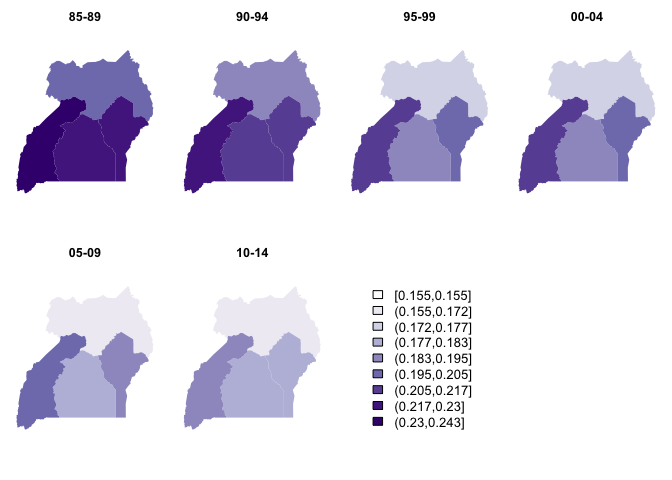

```r
mapPlot(countryname = "Uganda", results = results_rw2, geo = geo,
            countrysum = data, inlamod = inla_model)
```

We now map our the median estimates over time by region with a spaghetti plot using `spagPlot`.

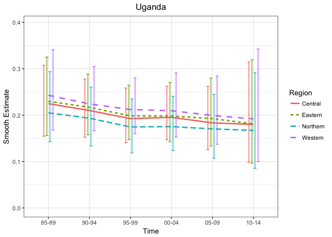

```r
spagPlot(countryname = "Uganda", results = results_rw2, geo = geo,
            countrysum = data, inlamod = inla_model)
```